# STATS 506 Final Project

Yingyi Yang

December 15, 2020

# **Introduction**

The majority of adults in the United States gain weight with age. Investigation on weight maintenance has long been the health concern of people to prevent obesity and the possible complications because of the obese state.

People’s weight is controlled by both internal and external factors. Nutrient intake can no doubtedly affect weight. Demographic factors (such as age, gender) and socioeconomic factors (such as education level and income) may affect adults’ weight as well. It thus makes sense to identify the key factors among them to provide people with guidence to maintain their weight. In this analysis, we would like to investigate that: For adults who weigh less than they were 10 years ago, what their current nutrient intake and demographic factors are considered important?

# **Data/Methods**

The 2015-2018 demographic, nutrient intake and weight history data are obtained from [NHANES](https://wwwn.cdc.gov/Nchs/Nhanes/). We select some of the variables that are of most interest. The response variable are transformed into binary according to whether the respondent’s weight are at least 5 pounds less than 10 years ago. Other covariates are standardized before model fitting.

We use function `featureSelection` to select the `n` most important features. The criteria for feature selection is set by the input argument `method`. Here we use two classification models: logistic regression and decision tree. We select features based on model and recursive feature elimination (RFE) method for each model, respectively. RFE is implemented using `feature_selection` in Python `sklearn` package. It can select features by recursively considering smaller set of features. Basically, it trains an estimator on the initial set of features, and prunes the least important feature either through a `coef_` or `feature_importances_` attribute. This procedure is repeated until the desired number of features is reached.

The detailed code can be founded in [github](https://github.com/YingyiYang/Stats506Final).

# **Results**

The descriptive statistics for the variables used in this analysis are shown in Table 1. There are 6,711 data points in which `Female` and `Wloss` are binary.

|  | Variable | Mean (range) | Standard deviation |
| --- | --- | --- | --- |
| 1 | Age | 58.22 (36.00 ~ 80.00) | 13.07 |
| 2 | Education | 3.46 (1.00 ~ 5.00) | 1.27 |
| 3 | Household income | 8.77 (1.00 ~ 15.00) | 4.44 |
| 4 | Energy | 2039.14 (14.00 ~ 8500.00) | 928.83 |
| 5 | Protein | 78.06 (0.00 ~ 545.20) | 40.45 |
| 6 | Carbohydrate | 240.34 (1.00 ~ 1222.34) | 116.88 |
| 7 | Sugars | 102.65 (0.50 ~ 980.92) | 71.52 |
| 8 | Fiber | 17.01 (0.00 ~ 103.40) | 10.79 |
| 9 | Fat | 81.23 (0.00 ~ 405.22) | 45.60 |
| 10 | Saturated fatty acids | 26.07 (0.00 ~ 149.15) | 16.49 |

[output cut: 5 more lines]

**Table 1.** Descriptive statistics of the dataset including dependent variable and independent variables.

We present results for two different methods of feature selections below. 5 features are selected for each case.

### 1. Model-based method

The results for logistic regression is quantified using the fitted coefficients that are statistically significant. Features with largest absolute coefficients are selected. Here we only have 4 significant features. On the other hand, the results for classification tree is quantified using feature importance.

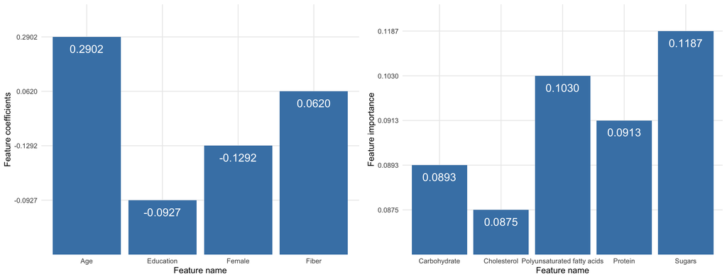

**Figure 1.** Important features selected using model-based method (left: Logistic Regression, right: Classification Tree).

### 2. Recursive feature elimination (RFE) method

With `RFE` function in Python `sklearn.feature_selection` package, we can specify the number of features that we want to keep, so that it can generate the top 5 important ones. For logistic regression, the top 5 are Age, Energy, Fat, Monounsaturated fatty acids, Female. For classification tree, the top 5 are Carbohydrate, Sugars, Saturated fatty acids, Monounsaturated fatty acids, Cholesterol.

# **Conclusion/Discussion**

We draw conclusions by comparing the results for the same classification model. For logistic regression, the common important features for both model-based and RFE methods are Age and Female. For classification tree, the common important features when we use different methods are Carbohydrate, Cholesterol and Sugars. We notice that only nutrient intake factors are important in the classification tree model given that we have standardized the variables before model fitting. Other important features that appear twice includes Monounsaturated fatty acids.

Since the goal of this analysis is to identify the important features rather than doing prediction, we cannot infer how these features can affect people’s weight loss based above analysis. Another reason is that we only have data for people’s most recent nutrient intake, which certainly cannot represent what they have taken in the past 10 years. Given that the question we want to answer focuses on people’s current status, we can conclude that the above features are the important ones for those who have less weight than 10 years ago.